# What is SpaDES?

October 2019

## Introductions

- name, bio, etc.
- what have you heard about `SpaDES`?
- have you used it?
- what excites you the most about learning it?

## Workshop goals

- day 1: broad overview and introduction to `SpaDES`
- day 2: model implementation in `SpaDES`
- day 3: define you `SpaDES` modelling needs, and start working on your module(s)

## Ecological modelling in `SpaDES`

- break down ecological processes into discrete events;
- organize ecological processes into `SpaDES` modules;
- rapidly prototype and develop complex ecological models in `SpaDES`;
- parameterize and evaluate simulation models;
- perform scenario analyses, *e.g.*, for decision support;
- build portable, reproducible models;
- share models, analyses, and code.

## Why is modelling important?

Models are everywhere. Complex models pose several challenges.

[figure not shown]

## 1. Many models, low integration

- different scientific teams/individuals develop models to investigate the same question - which to choose?
- these models sometimes vary in their degree of complexity - when is one more appropriate than the other?
- and are often written in different programming languages, sometimes making their comparison, integration and development harder (especially for those who are not the model authors!)

## 2. High complexity

- often solving a question, or problem, requires the cooperation of different teams, each contributing with distinct data and, possibly, models that need to be integrated;

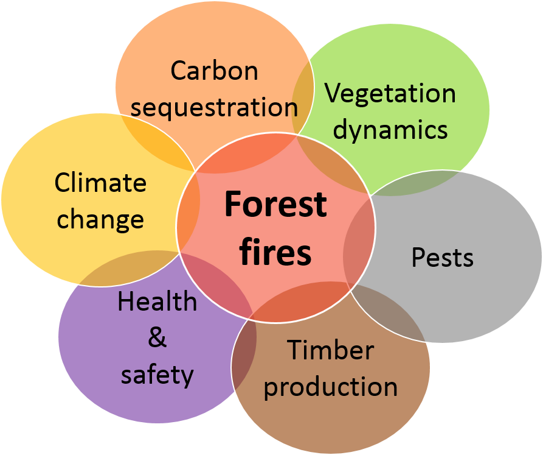

[figure not shown]

## 3. Era of *big data*

- data availability and volume are increasing *FAST*;
- today’s model, will be outdated tomorrow -> models need to be constantly updated, revised and re-validated and re-calibrated.

## 4. Reproducibility and transparency

- scientific method relies on repeated analyses to help verify whether hypotheses hold in different conditions -> science *must* be reproducible in order to progress;
- models (and modellers!) should be open to change and adaptation;
- results and conclusions *must* be shared with stakeholders, managers, policy makers and the general public.

## How do we tackle these issues?

**Continuous adaptive management**

- periodic re-assessment of the status of a situation or issue (e.g., the amount of waste a company produces)
- leads to the design and implementation of new solutions (e.g., recycling paper or using rain water)

## Continuous adaptive management

- In modelling terms, analyses and forecasts are repeated as new data, new methodologies and new or improved models arise
- Re-assessment of risk, inform decisions and influence policy making
- Feedback into the process of re-framing the initial problem/question

## Continuous adaptive management

Although this framework is ideal, it is only seldomly applied across the scientific community.

*Why?* Because we are yet far from developing our research in a way that is easily repeatable, “upgradeable” and shareable.

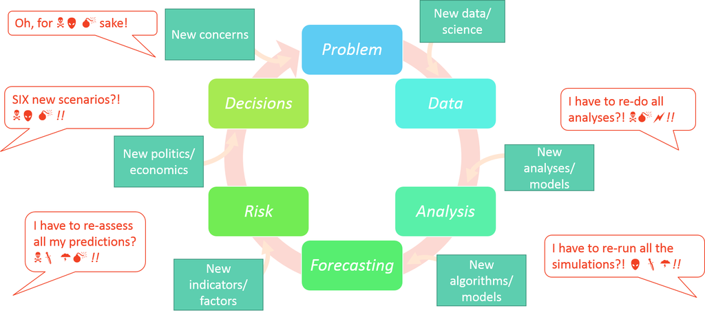

## Where do we go from here?

[figure not shown]

## What is `SpaDES`?

**Spa**tial **D**iscrete **E**vent **S**imulator

- modelling framework in the form of an ensemble of `R` packages
- provides modellers and non-modellers across different domains with a modelling tool that they can *control*, *apply* and *develop*.
- bridges gaps between modellers and model-users of different disciplines, between scientists, practitioners, managers, stakeholders and policy makers, and between scientists and the general public.

## `SpaDES`…

1. is written in `R`: a widely understood programming language, highly suited to statistical analyses, but flexible and fast enough to accommodate simulation work;
2. can be used for a wide-range of modelling approaches:
   - process-based models;
   - phenomenological models;
   - spatially-explicit models;
   - …

## `SpaDES`…

1. models are built of *modules*, i.e. self-contained, interacting pieces that execute a particular *event*, or process in the model;
2. *modules* can be made available across the entire `R` community if module-developers wish it so;
3. will soon include a web-app builder to make interactive simulation possible.

## **An example**

Our question(s): how will forest fires affect forest age? And how will climate change affect fire regimes and in turn the vegetation? How will timber supply be affected?

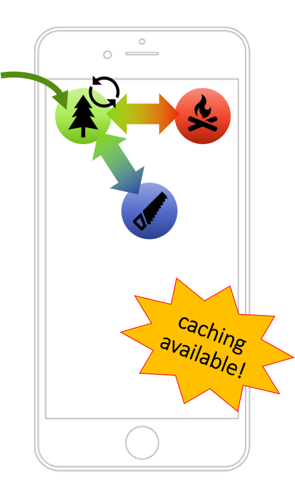

## To start we’ll need…

- a vegetation dynamics module - e.g. forestAge;
- a fire simulator - e.g. forestSuccessionBeacons modules;
- optional:
  - the interaction between fire and vegetation
  - statistical analyses/presentation of results

## Vegetation dynamics simulation

- Depending on how modules are built, the interaction between modules may or may not require additional modules.
- Similarly, the presentation of results and their analyses can be directly made within the module producing them, or *as posteriori* using another module.

## Add climate-change, timber supply models…

- climate change effects could be done by varying fire-related parameters (e.g. frequency and intensity of fires) in a simulation experiment.
- alternatively, additional module could simulate climate change effects, which would feedback into both fire parameters and vegetation.
- timber supply module could “read” the vegetation maps produced after fire simulations and calculate timber quantity and quality from forest conditions (e.g., surviving tree species and their age).

## Reserve, add new data, and re-run

- Provided that modules are able to download, read and treat data adequately, updating the simulations for new data is easy.
- `SpaDES` comes with a set of functions (via the `reproducible` package) that enable caching model structure, parameters and simulation results.
- This way, if new data only affects a section of the model, the user won’t have to repeat every step to update the simulations.

## Decorate and serve

Because models are not just for modellers, a shiny app building package is being developed to transform any `SpaDES` simulation into a web-app. This provides an interactive way of visualising results, as users can change simulation parameters and turn modules on and off, whilst observing how this impacts simulation results. Importantly, it can be particularly useful when conveying results to a non-expert or even the public.

## `shiny` web-app demos

- https://spades.shinyapps.io/ForestChange_ProofOfConcept/
- http://landweb.ca

## Where to get help

- package help docs (*e.g.*, [overview of `SpaDES` package](http://www.rdocumentation.org/packages/SpaDES/versions/1.2.0/topics/SpaDES-package)):

```r
?SpaDES
```

- package vignettes ([link](https://github.com/PredictiveEcology/SpaDES/wiki/Help-Vignettes))
- `SpaDES` wiki ([link](https://github.com/PredictiveEcology/SpaDES/wiki/))
- `SpaDES` user group ([link](https://groups.google.com/d/forum/spades-users))
- bug reports ([link](https://github.com/PredictiveEcology/SpaDES/issues/))

## Next

- Case studies using `SpaDES`
- Thinking the `SpaDES` way.